# Forced Labor Economic Model

Sustainable Fisheries Group, UCSB

August 6, 2018

# Goal

- Identify vessels that routinely behave in a way that indicates lower labor cost than other similar vessels

# Assumptions

- For vessels in the same fishery (flag and gear) and in a given time period (monthly), the fishery shares a common stock.
- Individual vessels are profit maximizing, but for a given fishery and time period all points globally have a spatially uniform profitability. Points close to port will have smaller levels of the stock, but are less costly to travel to. Points further away from port will have higher levels of the stock, but are more costly to travel to.
- Based on certain vessel characteristics (flag, gear, engine power, length, and tonnage), vessel operators will travel an optimum distance from port to give them the same profitability as other vessels in the fishery.
- All similar vessels have the same variable labor cost, variable fuel cost, and variable subsidy benefits when not employing forced labor. These variable costs and benefits are assumed to be linearly proportional to both travel distance and fishing effort.
- Vessels employing forced labor will have lower variable labor costs.

# Equations

Average revenue for a given fishing area, $\overline{R_i}$ is given as follows, where $q$ is catchability, $B_i$ is the biomass in each area fished, $\overline{E_i}$ is the average fishing effort in the fishing area, and $p$ is price.

$$\overline{R_i} = q B_i \overline{E_i} p$$

Average cost for a given fishing area, $\overline{C_i}$, is given as follows, where $T_i$ is the travel distance from port to reach fishing are $i$, $c_{fuel}$ is the variable fuel cost, $c_{labor}$ is the variable labor cost, and $s$ is the variable subsidy benefit:

$$\overline{C_i} = (T_i + \overline{E_i})(c_{fuel} + c_{labor} - s)$$

Combining the equations for $\overline{R_i}$ and $\overline{C_i}$, we get the average profit equation in each fishing area:

$$\overline{\Pi_i} = q B_i \overline{E_i} p - (T_i + \overline{E_i})(c_{fuel} + c_{labor} - s)$$

Solving for $B_i$ yields the following:

$$B_i = \frac{\overline{\Pi_i} + (T_i + \overline{E_i})(c_{fuel} + c_{labor} - s)}{q \overline{E_i} p}$$

This demonstrates that biomass will be higher in areas further from port ($B_i$ increases as $T_i$ increases). Next, we denote $\widetilde{\Pi_i}$ as the profit of vessels using forced labor. We can therefore write the following equation, where $\tilde{c_{labor}}$ is the cost of forced labor, which will be lower than $c_{labor}$.

$$\widetilde{\Pi_i} = q B_i \overline{E_i} p - (T_i + \overline{E_i})(c_{fuel} + \tilde{c_{labor}} - s)$$

Next, we can plug in $B_i$ to this equation:

$$\widetilde{\Pi_i} = q \overline{E_i} p \left(\frac{\overline{\Pi_i} + (T_i + \overline{E_i})(c_{fuel} + c_{labor} - s)}{q \overline{E_i} p}\right)- (T_i + \overline{E_i})(c_{fuel} + \tilde{c_{labor}} - s)$$

Which simplifies as follows:

$$\widetilde{\Pi_i} = \overline{\Pi_i} + (T_i + \overline{E_i})(c_{labor} - \tilde{c_{labor}})$$
Since $c_{labor}$ will always be greater than $\tilde{c_{labor}}$, and vessels are assumed to be profit maximizing, vessels using forced labor will therefore maximize their distance from port $T_i$.

# Examples

We use the following linear regression to predict maximum distance from port as a function of vessel characteristics:

$$max\_dist\_from\_port \sim length + tonnage + engine\_power +$$
$$factor(flag) + factor(gear) + factor(year) + factor(month)$$

## Thailand

The training data set is composed of all Thai-flagged fishing trips from 2012-2016. Importantly, we exclude any vessels from the training set that are known to be offenders. We use this model to predict maximum distance from port for all fishing trips, including those known to be offenders. The observed versus predicted model relationship is visualized as follows. Note that all known-offenders are significant outliers from the model, and exhibit higher than expected maximum distance from port.

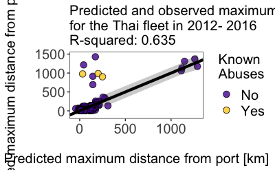